# Examples with evtools

This vignette provides worked examples showing different approaches to executing modeled events.

Author

Kyle Baron

Published

October 24, 2024

# Overview

`evtools` is a [plugin](https://mrgsolve.org/user-guide/plugins.html#sec-plugin-evtools) for mrgsolve that exposes extra code you can use in your model code to execute dosing or other events in a simulations. Normally, these doses are given through a data set. However, sometimes we’d like to alter the dose regimen in response to how the system advances in time and that can only be done through mechanisms such as `evtools`. Note that the examples shown here do execute dosing regimens in a variety of ways, none of it is actually in response to the ongoing simulation. I did this for clarity, keeping the focus on the dosing syntax rather than complexity in responding to other parts of the system.

All of the code for running these examples is available in a [github](https://github.com/mrgsolve/dynamic-dosing) repository.

## Setup

We’ll use these packages to run the code.

```r
library(mrgsolve)
library(dplyr)
```

And I’m writing these examples with the following mrgsolve version

```r
packageVersion("mrgsolve")
```

```
[1] '1.5.2.9000'
```

## Base model

All of the examples are based on a simple one-compartment PK model shown here:

```c
[ plugin ] evtools

[ set ] outvars = "CP"

[ param ] CL = 1, V = 32, KA = 2, DOSE = 100

[ pkmodel ] cmt = "A1,A2", depot = TRUE

[ event ]

// Do something <------ we'll vary what is in this block

[ error ] capture CP = A2/V;
```

I’ll make some minor tweaks to parameter values and outputs from time to time, but the model will largely stay like this, except for the `$EVENT` block. Each example will update the code in that block to illustrate different functionality provided by `evtools`.

Note that you need to invoke the `evtools` plugin to get this code to work

```c
[ plugin ] evtools
```

Also note that we write code to do dynamic dosing in the `[ event ]` block

```c
[ event ]

// Do something <------ we'll vary what is in this block
```

This is a new block with mrgsolve version 1.5.2. The block functions like and is called just prior to `$ERROR` (or `$TABLE`). So the important part here is that your event code gets called just as the system advances to the next time and just prior to writing outputs for the most recent advance. While you can also run model event code in `$PK`, we recommend always writing the code in `$EVENT`.

Let’s get to the worked examples.

# Examples

## evtools-0 single dose

In this event block, we just need to execute a single dose to `A1` right when we come to a new individual

```c
[ event ]

if(NEWIND > 1) return;

evt::bolus(self, DOSE, 1);
```

Because we don’t need to customize this dose at all, pass `self` as the first argument and `evt::bolus` will “send” it back to mrgsolve for you. Couldn’t be easier!

```r
idata <- expand.idata(DOSE = c(100, 200, 300))
idata
```

```
  ID DOSE
1  1  100
2  2  200
3  3  300
```

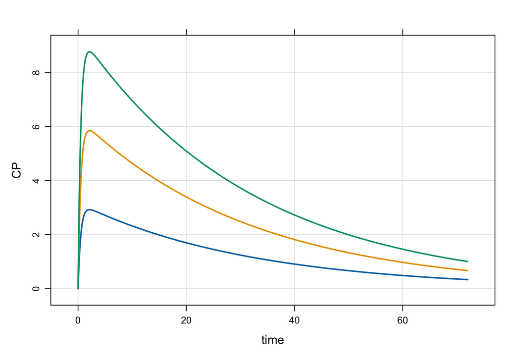

```r
mod <- mread("model/evtools-0.mod")
out <- mrgsim(mod, idata = idata, end = 72, delta = 0.2)
plot(out)
```

## evtools-1 additional doses

In this example, we give multiple doses by specifying the dose interval and the number of additional doses.

```c
[ event ]

if(NEWIND > 1) return;

evt::ev dose = evt::bolus(DOSE, 1);
evt::ii(dose, INTERVAL);
evt::addl(dose, TOTAL-1);
self.push(dose);
```

Here, we call `evt::bolus()` *without* passing `self`. This means we’ll get and object back that we can customize, adding the dosing interval `ii` and number of additional doses `addl`. Once we’re done customizing, we need to `push` the object back for processing.

First, an example with a single dose level

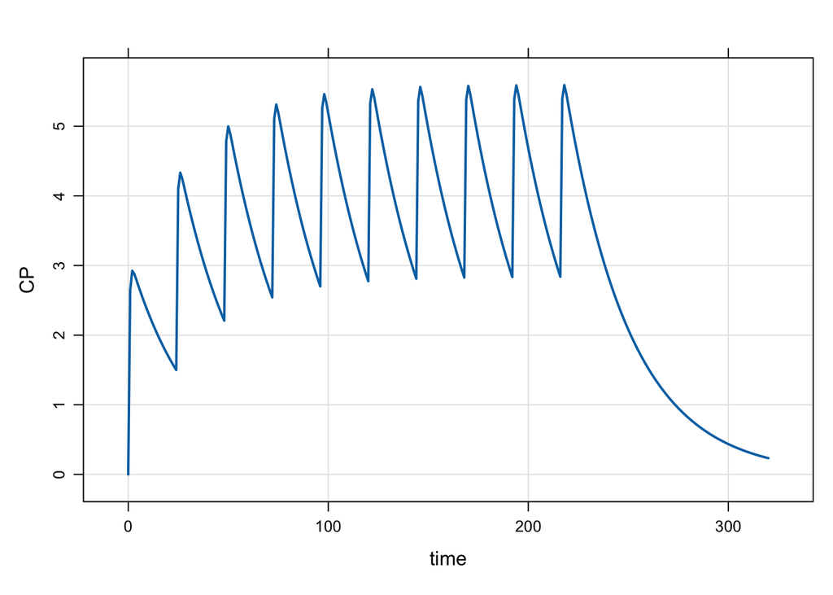

```r
mod <- mread("model/evtools-1.mod")
out <- mrgsim(mod, end = 320)
plot(out)
```

Next, look at multiple dose levels

```r
idata <- expand.idata(DOSE = c(100, 300, 1000))
head(idata)
```

```
  ID DOSE
1  1  100
2  2  300
3  3 1000
```

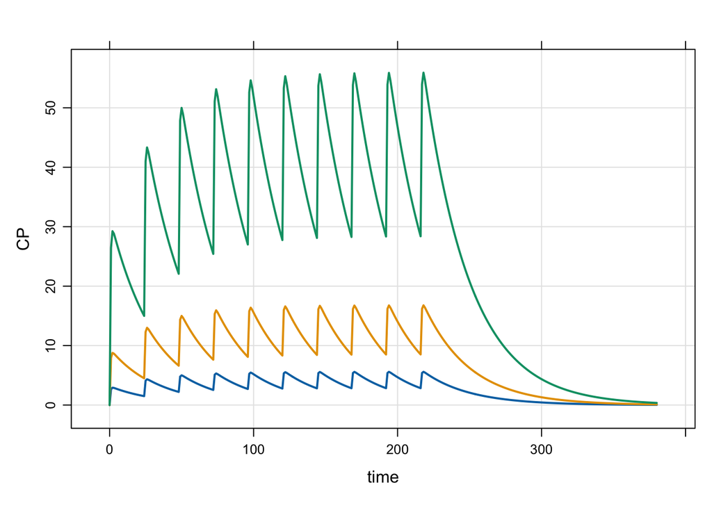

```r
out <- mrgsim(mod, idata = idata, end = 380)
plot(out)
```

We can also look at a single dose and multiple dose intervals

```r
idata <- expand.idata(DOSE = 100, INTERVAL = c(6, 12, 24, 48))
idata <- mutate(idata, TOTAL = 10*24/INTERVAL)
head(idata)
```

```
  ID DOSE INTERVAL TOTAL
1  1  100        6    40
2  2  100       12    20
3  3  100       24    10
4  4  100       48     5
```

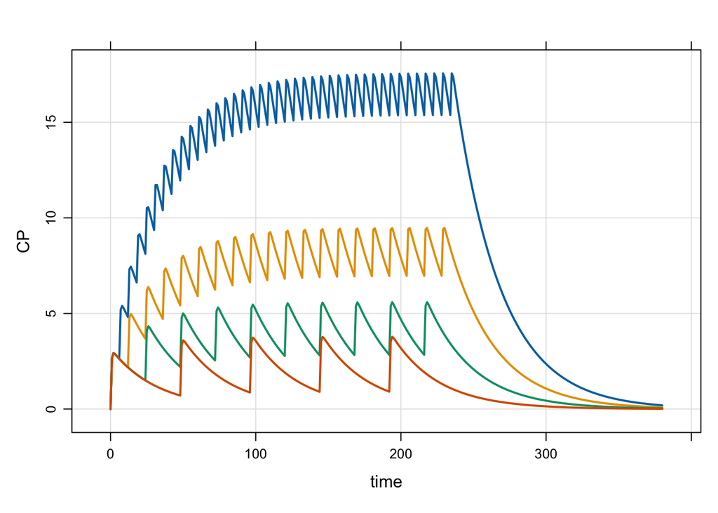

```r
out <- mrgsim(mod, idata = idata, end = 380)
plot(out)
```

## evtools-2 additional doses, steady state

In this example, we create an object for a bolus dose, then modify it to dose to steady state at a given dosing interval (a parameter called `INTERVAL`) and give some additional doses (a parameter called `TOTAL`).

```c
[ event ]

if(NEWIND > 1) return;

evt::ev dose = evt::bolus(DOSE, 1);
evt::ss(dose, 1);
evt::ii(dose, INTERVAL);
evt::addl(dose, TOTAL-1);
self.push(dose);
```

Because we’re working on this event object, we need to `push()` it back to mrgsolve for processing.

First, do a single dose level to steady state

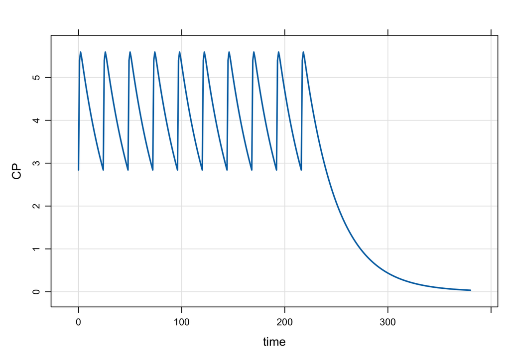

```r
mod <- mread("model/evtools-2.mod")
out <- mrgsim(mod, end = 380)
plot(out)
```

Next look at several dose levels, administered to steady states

```r
idata <- expand.idata(DOSE = c(100, 200, 300))
head(idata)
```

```
  ID DOSE
1  1  100
2  2  200
3  3  300
```

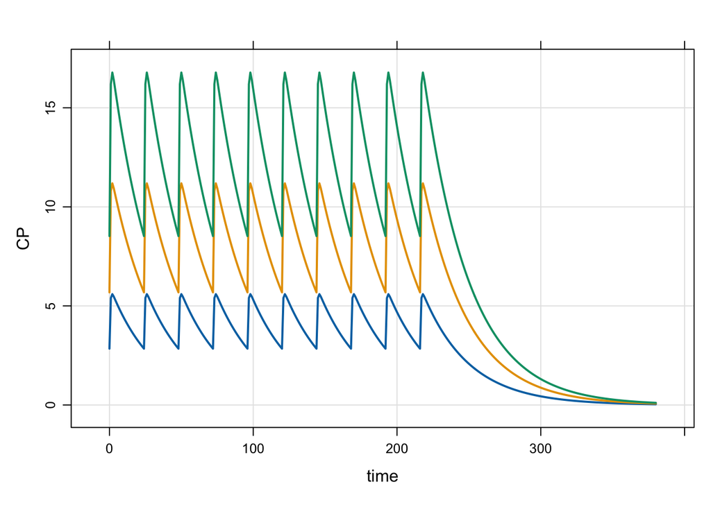

```r
out <- mrgsim(mod, idata = idata, end = 380)
plot(out)
```

## evtools-3 multiple doses, user-controlled A

This example also shows multiple doses, but rather than scheduling them through `addl()`, we write our own code to manage the dosing interval. The benefit of this “user-controlled” approach is that you always know when the next dose will happen. Although not illustrated here, this allows you to delay a dose or move a dose up in time.

```c
[ event ]

if(std::fmod(TIME,INTERVAL)==0) {
  evt::infuse(self, DOSE, 1, DOSE/OVER);
}
```

If `INTERVAL` is 24, we will get doses every 24 hours, as shown below

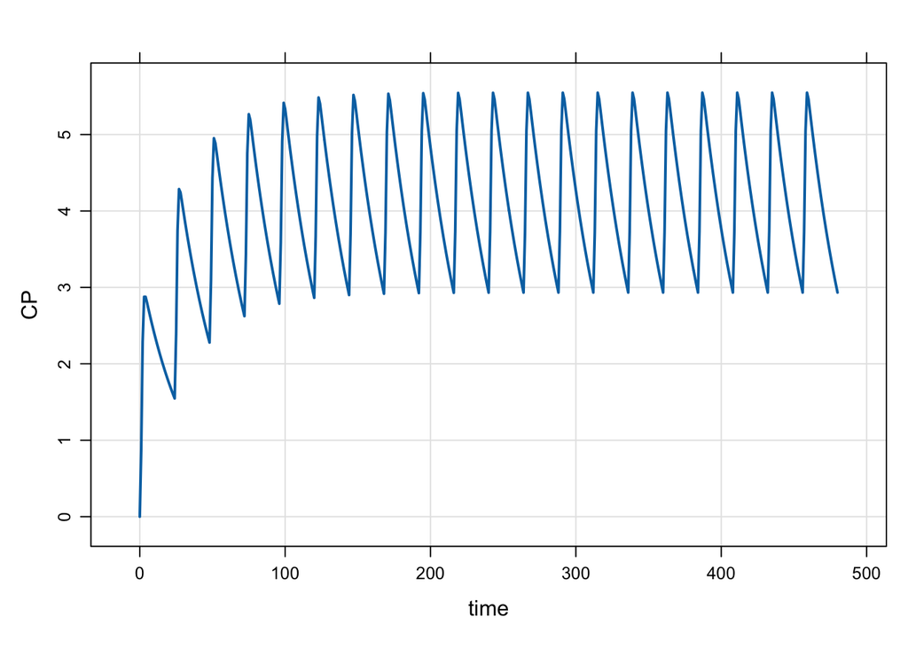

```r
mod <- mread("model/evtools-3.mod")
out <- mrgsim(mod, end = 480)
plot(out)
```

Next, we show how you can simulate from this model, but with several different dosing intervals.

```r
idata <- expand.idata(DOSE = 100, INTERVAL = c(6, 12, 24, 48))
idata <- mutate(idata, TOTAL = 10*24/INTERVAL)
head(idata)
```

```
  ID DOSE INTERVAL TOTAL
1  1  100        6    40
2  2  100       12    20
3  3  100       24    10
4  4  100       48     5
```

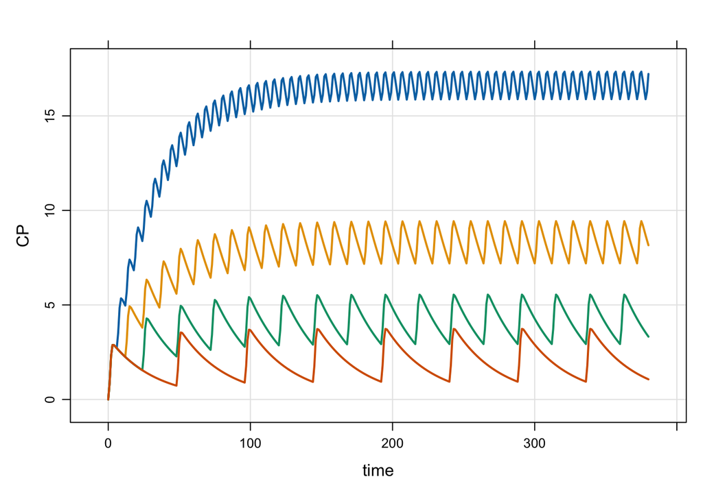

```r
out <- mrgsim(mod, idata = idata, end = 380)
plot(out)
```

## evtools-4 multiple doses, user-controlled B

This example is just another way to implement the bookkeeping required to track when the next dose is given, and alter the dosing time if needed. I think this approach is a little more flexible than what we saw in `evtools-3`.

```c
[ event ]

if(TIME > END) return;

if(NEWIND <=1 ) {
  double nextdose = 0;
}

if(evt::near(TIME, nextdose)) {
  evt::infuse(self, DOSE, 1, DOSE/OVER);
  nextdose = nextdose + INTERVAL;
}
```

The `evt::near()` function works just like the [dplyr function](https://dplyr.tidyverse.org/reference/near.html).

First, simulate a single dose level and dosing duration

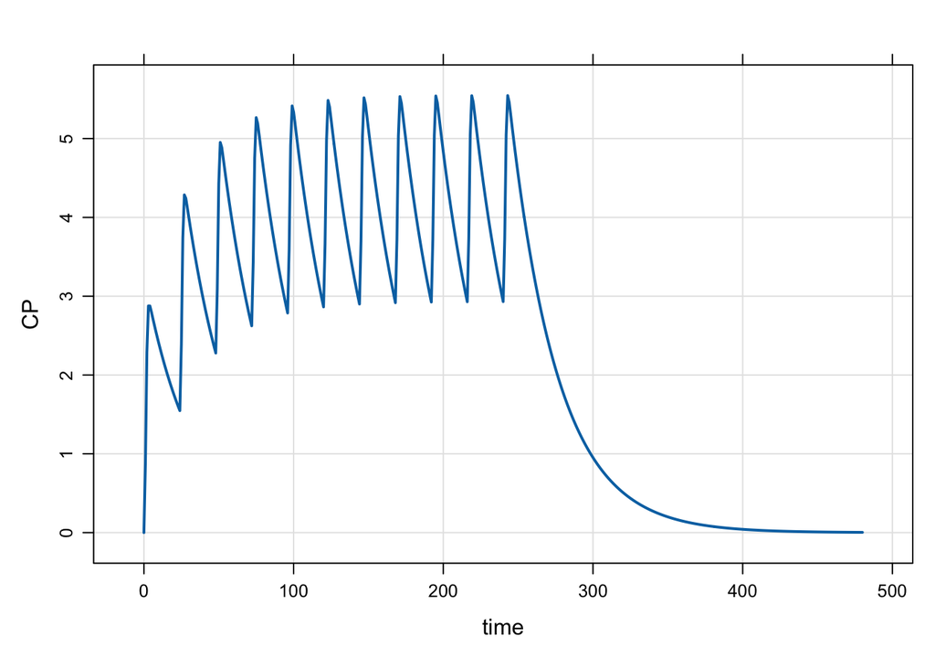

```r
mod <- mread("model/evtools-4.mod")
out <- mrgsim(mod, end = 480)
plot(out)
```

Next, do some sensitivity analysis on `END`, a parameter controlling the duration of dosing.

```r
idata <- expand.idata(END = c(60, 120, 240, 480, 600))
head(idata)
```

```
  ID END
1  1  60
2  2 120
3  3 240
4  4 480
5  5 600
```

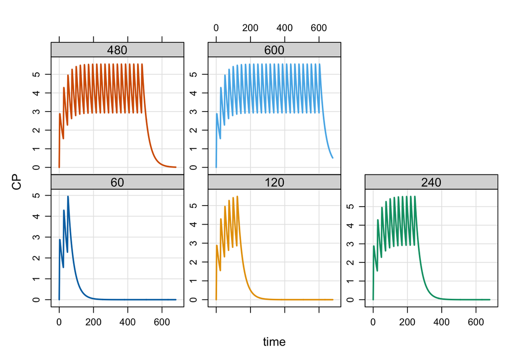

```r
out <- mrgsim(mod, idata = idata, end = 680, recover = "END")
plot(out, CP ~ time | factor(END))
```

See `model/evtools-4.mod` for more details on how this is set up.

## evtools-5 start dosing later

This example looks just like the `evtools-2` model, but this time we’ll start the dose later in the simulation. In contrast, `evtools-2` started the dosing “now”.

```c
[ event ]

if(NEWIND > 1) return;

evt::ev dose = evt::bolus(DOSE, 1);
evt::rate(dose, DOSE/OVER);
evt::retime(dose, 120);
evt::ss(dose, 1);
evt::ii(dose, 24);
evt::addl(dose, 5);

self.push(dose);
```

In this example, we’ll again simulate several dose levels

```r
mod <- mread("model/evtools-5.mod")
idata <- expand.idata(DOSE = c(100, 150, 200))
head(idata)
```

```
  ID DOSE
1  1  100
2  2  150
3  3  200
```

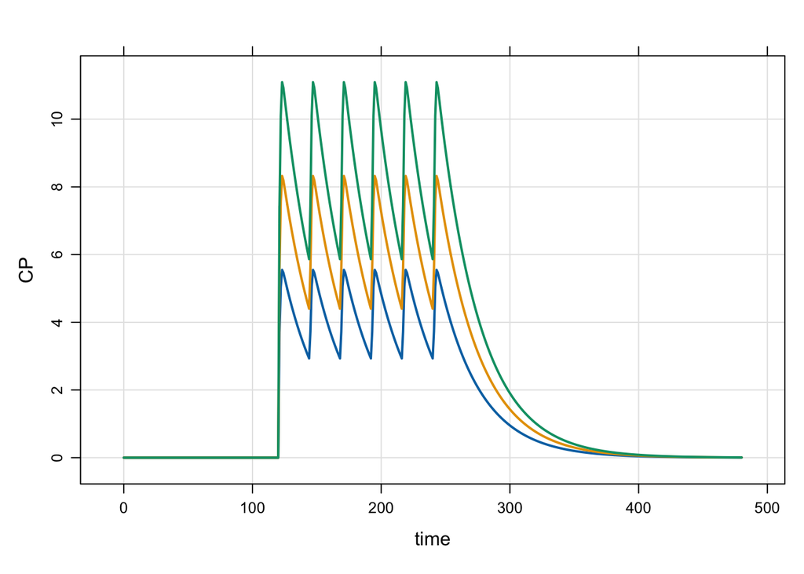

```r
out <- mrgsim(mod, idata = idata, end = 480)
plot(out)
```

## evtools-6 reset the system

This is a simple intervention to reset the system every 72 hours. I’m including the `$PK` block as well, to show that the compartment 2 initial value is 1000 units. By resetting the system every 72 hours, it appears like we could be dosing with that dose interval. But the simulation is different than every 72 hour dosing because we reset the system so the Amax in compartment 2 is always 1000; if we were dosing 1000 mg Q72 hours, Amax would increase over time due to accumulation.

```c
[ pk ]
A1_0 = 0;
A2_0 = 1000;

[ event ]

if(std::fmod(TIME,72)==0 || NEWIND <= 1) {
  evt::reset(self);
}
```

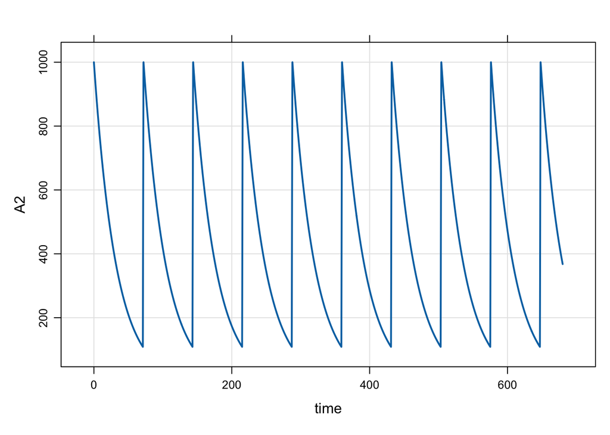

```r
mod <- mread("model/evtools-6.mod")
out <- mrgsim(mod, end = 680)
plot(out)
```

## evtools-7 reset and dose

This example shows how we can reset the system and then dose.

```c
[ event ]

if(NEWIND <= 1) {
  evt::ev dose = evt::bolus(50, 1);
  evt::ii(dose,12);
  evt::addl(dose,22);
  self.push(dose);
}

if(evt::near(TIME,290)) {
  evt::ev dose = evt::reset(100, 1);
  evt::ii(dose, 24);
  evt::addl(dose,10);
  self.push(dose);
}
```

The simulation starts out with a sequence of 23 doses, given every 12 hours. Then at 290 hours, we reset the system and dose 100 mg every 24 hours. In this example, we continue giving bolus doses after the reset. We could also reset and give infusions by passing the infusion rate in to `evt::reset()`.

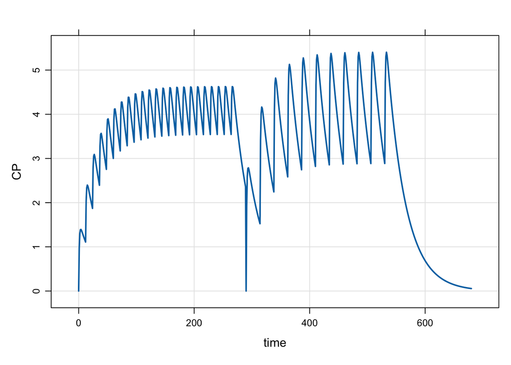

```r
mod <- mread("model/evtools-7.mod")
out <- mrgsim(mod, end = 680)
plot(out)
```

## evtools-8 replace

The replace functionality works like a bolus dose, but the amount in the compartment is overwritten with `amt` rather than adding `amt` to the current amount in the compartment The replace functionality isn’t easily illustrated with a PK model like this; usually we replace with a unit indicator or something along those lines. But I’ll force the code into this model so you can see what it happens.

In the example, we start an infusion in to the depot compartment at 48 hours and let it run until 148 hours. At 150 hours, we drop the amount in the central compartment to 10 and then watch the end of absorption happen.

```c
[ event ]

if(evt::near(TIME, 48)) {
  evt::infuse(self, 300, 1, 3);
}

if(evt::near(TIME, 150)) {
  evt::replace(self, 10, 2);
}
```

It’s not a simulation we’d normally do, but including it here to show the syntax for replacing compartment amounts.

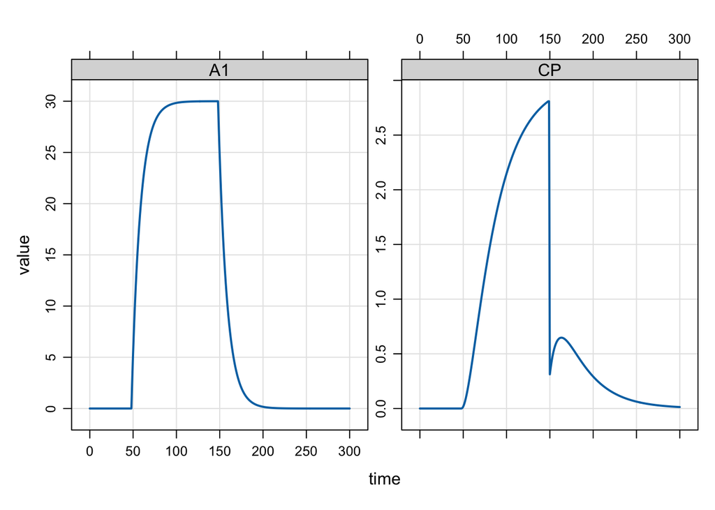

```r
mod <- mread("model/evtools-8.mod")
out <- mrgsim(mod, end = 300)
plot(out)
```

`replace()` is also *similar* to `reset()`. Specifically, when you reset or replace, there is a discontinuity introduced in the simulation. The ODE sovler (if used) resets at the event time and starts again from the event time.

Some differences between `replace()` and `reset()` are

1. `replace()` works on a single compartment, `reset()` works on all compartments
2. `replace()` sets the compartment amount to a user-chosen value, `reset()` returns compartment amounts back to the initial condition

## evtools-99 automatic dose regimen

This example shows how you can create a `regimen` object that will implement a dosing regimen that can be updated as the simulation proceeds. Notice that we have some additional code here, including declaring this `regimen` object (`reg`) in the global block.

```c
[ global ]
evt::regimen reg;

[ event ]

if(NEWIND <=1) reg.init(self);

reg.ii(INTERVAL);
reg.amt(DOSE);
reg.rate(reg.amt() / OVER);
reg.until(UNTIL);

reg.execute();
```

Previously, we implemented dosing regimens by scheduling additional doses through `evt::addl()` and we’ve also implemented doing regimens where we have had to do the bookkeeping to track the dosing interval and always setting the time for the next dose. Using `addl()` gets you out of doing the bookkeeping, but all the doses in the regimen are set up and you can’t change what happens in the future. User-implemented regimens are more flexible, but require some creativity to do the bookkeeping. Using a `regimen` object splits that difference, allowing you to start dosing at a given interval with mrgsolve tracking when is the next dose time. But flexibility is retained with the ability to update dose amount, dose interval, duration of dosing on the fly, with those changes automatically getting folded into the execution of the regimen.

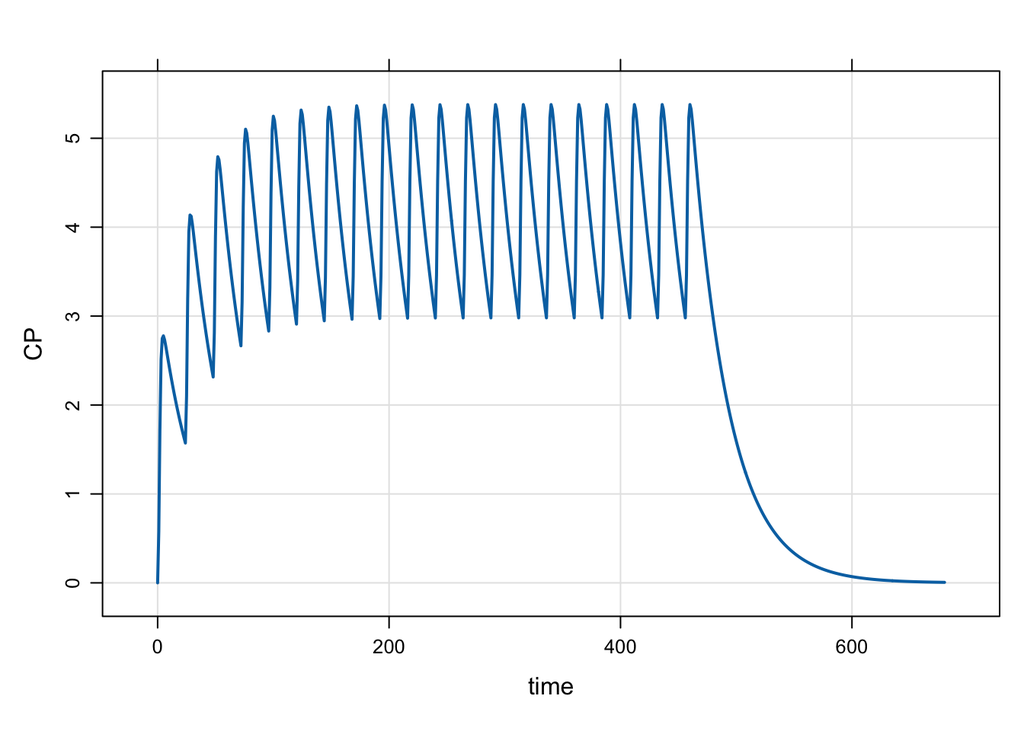

```r
mod <- mread("model/evtools-99.mod")
out <- mrgsim(mod, end = 680)
plot(out)
```

```r
idata <- expand.idata(DOSE = c(100, 150, 300), UNTIL = c(240,480))
idata
```

```
  ID DOSE UNTIL
1  1  100   240
2  2  150   240
3  3  300   240
4  4  100   480
5  5  150   480
6  6  300   480
```

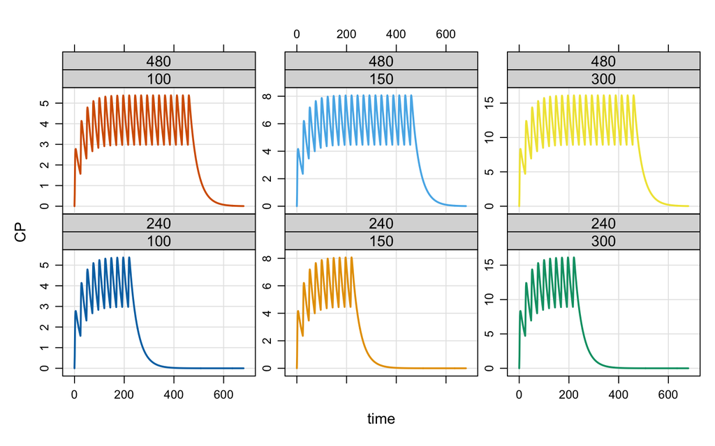

```r
out <- mrgsim(mod, idata = idata, end = 680, recover = "DOSE,UNTIL")
plot(out, CP ~ time |factor(DOSE)*factor(UNTIL))
```

# Source code

You can find the source code for this vignette here: https://github.com/mrgsolve/dynamic-dosing

You can find the source code for these models here: https://github.com/mrgsolve/dynamic-dosing/tree/main/model